# Practice Problems: Statistics for Business Analytics

Author

Riley Svensson

## Introduction

In the field of business analytics, applied statistics play a crucial role in making data-driven decisions. This document serves as a comprehensive practice resource designed to reinforce key statistical concepts through some fun and practical applications. The problems presented are simplified for better understandability while retaining the realism of real-life scenarios, making the learning experience more engaging than typical statistics exercises. Through a series of carefully crafted problems and detailed solutions, this practice test aims to enhance the analytical skills necessary for tackling real-world challenges. Whether you’re a student seeking to deepen your knowledge or a professional looking to refresh your skills, these practice problems provide a valuable opportunity to engage deeply with the material and gain confidence in applying complex yet essential statistical techniques. *Keep an eye out for trick questions*

```r
library(kableExtra)
```

# Problem 1

##### (Course Concept(s): Expected Value / Variance & Standard Deviation)

Riley is currently a part of 4 different fantasy football leagues, each of which has a grand prize for winning 1st place (winner takes all), and a buy-in to enter the league. A table of the league’s 1st place prize values, buy-ins, and subjective probabilities of success are displayed below. Riley has a track record of placing 1st in League’s 1 and 3, making the probability of winning greater than 1/n, where n is the number of players in the league. For leagues 2 and 4, assume the probability of success is (1/n), and don’t forget the complement rule. Fill in the rest of the table, to include the profit column probabilities of losing, and use this to compute the expected value of Net Profits (P).

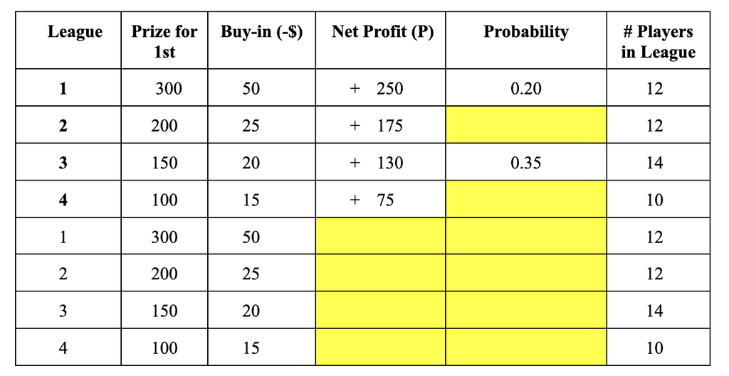

a) Solve for E(P).

b) Explain in context what this number from the previous part is “expected”?

c) Would it be a good idea for Riley to constantly enter these 4 leagues if he simply wishes to profit in the long-run? What if he expects to make 100$?

d) Compute and interpret Var(P) , SD(P) in context.

# Problem 2

##### (Course Concept(s): Independence / Basic Probability)

Fortnite is a popular video game that follows a battle royale format in which 100 players, are dropped into a map in teams of 4, with the purpose of being the last team standing. Assuming that the placement in a previous game has no effect on the placement of the next game:

a) What’s the probability that my team win’s 3 games in a row?

b) What about the probability that you lose 2 in a row, then win 2 in a row?

c) Are you more likely to lose 2 in a row then win 2 consecutive, than win 3 straight? By how much?

d) Given that you lost the last game, what is the probability that you win the next?

# Problem 3

##### (Course Concept(s): Basic Probability)

Beer die is a popular college game in SLO that incorporates a 4 x 8 ft wooden board that sits on a table, with 4 cups on each of its corners. A dice is thrown into the air with the purpose to hit the other team’s half of the board, and less likely into one of their 2 cups. **(Assume that the thrower does not miss the table, the die is equally likely to land anywhere on the table, and that a cup has a 3 inch diameter).**

a) Without calculating, what is the probability that you throw a die that lands on the opposing side of the board?

b) Find the probability that the die lands in 1 particular opponent’s cup.

c) What about either of the opposing cups?

# Problem 4

##### (Course Concept(s): Conditional Probability Calculations)

At my house, the outcome of my roommates taking out the trash (to the bins) is dependent on two factors, whether it’s a weekend or weekday, and if they are happy or unhappy. The subjective probability that they are happy is 0.7, create a two way table representing this distribution, and use it to answer the questions below: **(Hint: the probability of being a weekend is 2 days of the 7 days of the week)**

a) What is the probability that they take out the trash, while Happy and on a weekday? What about the opposite, while unhappy on the weekend?

b) Given it’s a weekday, what’s the probability of them taking out the trash while happy vs unhappy? Which is more likely and by how much? Interpret in context.

c) Given that they are unhappy, what’s the probability they take it out on a weekday vs weekend? Interpret the compared probabilities.

d) What is the total probability of them taking it out when happy on a weekend, OR when happy on a weekday.

# Problem 5

##### (Course Concept(s): Discrete Random Variables / Simulation Process / Expected Value )

A soccer player’s number of goals made out of 10 penalty kick attempts takes a Poisson distribution below with a parameter of 4.5. Use the Pmf of a Poisson distribution to fill in the table:

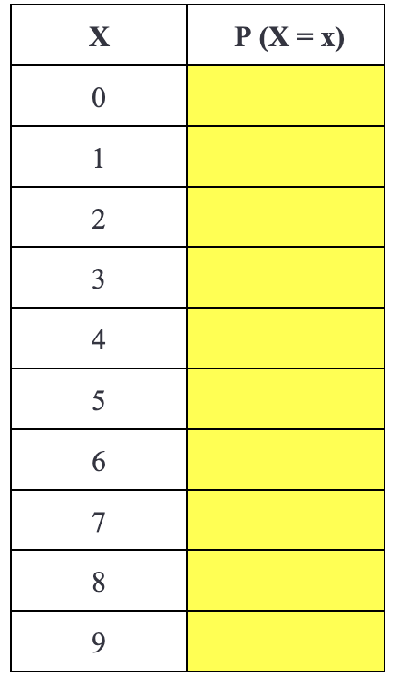

a) Find E(X), interpret, and explain why this makes sense conceptually.

b) Find $P (X\ge6)$ and interpret.

c) How many times more times likely to score above 5, than 5 and below? (P(X > 5) / (P(X <= 5)

d) Explain two ways that you could simulate this process to approximate the Expected value of goals scored in 10 penalty attempts. (Hint: Create a spinner for #2)

# Problem 6

##### (Course Concept(s): Continuous Random Variables / Probability Density Functions / Uniform & Exponential Distributions)

Imagine you work at a surfboard manufacturing factory as a quality control analyst. In this role you are tasked with ensuring that the surfboard’s sold are reaching the average life-span marketed by our company. Assume the durability of a surfboard (in hours of use) always falls between the lower and higher bound of 400 to 700 hours.

a) What is the probability that a randomly selected surfboard from our factory will last more than 650 hours? (Sketch a picture and use geometry to solve)

b) If our 1-year warranty is typically measured at around 500 hours of surfboard use, what percentage of the surfboards are expected to fail before reaching this point? (Use pdf to set up and integral & compute.)

c) A customer claims that their surfboard only lasted 410 hours. What are the chances of this and what does this infer about the customer’s claim? (Hint: compare to $\alpha$ = 0.05)

d) What is the probability of a surfboard lasting exactly 650 hrs?

e) Assume that a surfboard’s durability instead follows exponential distribution with a $\mu = 550$ hours, re-compute parts a and b.

# Problem 7

##### (Course Concept(s): Bivariate Normal Distributions / Variance & Standard Deviation / Covariance & Correlation)

Assume that college runners at a track meet are forced to enter both the 100 meter and 200 meter dashes. The times from both of these races, time 1 (T1), and time 2 (T2), follow a Bivariate Normal distribution. Race 1’s average time was 12 seconds with a standard deviation of 2 sec, and Race 2’s average time 22 seconds with a standard deviation of 5 sec, with a correlation ($\rho$) of 0.85.

a) Compute $Var(T1+T2)$ and $SD(T1+T2)$. Interpret in context.

b) Find the probability that a runner’s total time for both races was above 30 seconds.

c) Find the probability that a runner’s total time for both races was below 26 seconds.

d) Find the probability that a runner has a faster time for Race 1 than Race 2. Why does this make conceptual sense?

# Problem 8

##### (Course Concept(s): Normal Distributions / Simulate Coding)

8) Assume that the number of rap genre songs Riley plays each hour follows a normal distribution with a $\mu$ = 12, and a standard deviation of 3 songs.

a) Use coding to simulate this distribution.

b) Use the simulation results to approximate the probability that Riley play’s less than 8 rap songs in an hour. Compute using p-norm and compare your results.

c) Use the simulation to approximate the probability that Riley play’s more than 20 songs in an hour.

# Problem 9

##### (Course Concept(s): Percentiles / Cumulative Distribution Functions / Quantile Functions / Normal Distributions)

Riley is currently training in an attempt to find the optimal amount of time he spends in an ice bath, by researching the trends of other athletes. He discovers from Banner Health’s ice bath blog that the time athletes typically spend in an ice bath takes a normal distribution with a mean of 12.5 minutes and a standard deviation of 1.25 minutes. Compute $P(x)$ and interpret each value:

a) What is the probability that a randomly selected athlete spends more than 15 minutes in the ice bath?

b) It is said that top 5% of athletes who spend the most time in ice baths gain the highest benefits of recovery. What is the minimum time an athlete must spend in the ice bath to be in the top 5%?

c) If Riley longest time spent in an ice bath is 14 minutes, what percentile does this time correspond to among the distribution of athletes ?

d) If he wishes to have a longer time than 75 % of athletes what would his time need to be?

# Problem 10

##### (Course Concept(s): Joint & Conditional Distributions)

Riley currently owns 5 different surfboards ranging from sizes small to large, and labeled 1 through 5 respectively. On a weekend, Riley surfs on both days, we’ll call these Day 1 and Day 2, and selects 1 of his 5 boards to go out each day. Each board selection on a given day is random, as it depends on the surf report for that day. Suppose that Riley surf’s on two days every weekend and a potential outcome of the 2 days could be (Day 1 - Board 1, Day 2 - Board 5). Let X be the number of distinct surfboards used over the two days. Let Y be the number of days where Riley surfed a bigger board (4 or 5). Riley prefers all boards the same so there is an equally likely chance of selection for each.

a) Create a table of the different outcomes of board selection and corresponding values of X, Y

b) Create two table’s with the marginal distributions of X and Y .

c) Create a table with the joint distribution of X and Y.

d) Create two tables with the conditional joint distributions of $Y|X$ and $X|Y$ , and interpret a value from each table.

e) Are X and Y independent? Prove this with a calculation and explain.

### Sources:

6. Symbolab Integral Calculator:

   https://www.symbolab.com/solver/step-by-step/%5Cint_%7B0%7D%5E%7B500%7D%CE%BBe%5E%7B-%CE%BBx%7Ddx?or=input
7. 100 Meter Dash Times:

   https://conditionandnutrition.com/average-time-to-run-100m-data-table-by-age-and-ability/
8. 200 Meter Dash Times:

   https://trackspikes.co.uk/good-200m-time/
9. Athlete Ice Bath Times:

   https://www.bannerhealth.com/healthcareblog/teach-me/ice-baths-are-they-worth-it#:~:text=Cold%2Dwater%20immersion%2C%20also%20known,into%20the%20ice%20bath%20trend